# Gsynth implementation

ME

## Initialize

```r
rm(list=ls())
```

```r
# Main
library(gsynth)
library(panelView)

# Instrumental
library(dplyr)
library(leaflet)
library(tidyr)
library(ggplot2)
```

## Load data and variables

```r
main_dta2 <- readRDS("data/main_dta.rds")
nuts_treated <- readRDS("data/nuts_sf_treated") %>%
  sf::st_as_sf()
```

## Add variables (temporal)

```r
# investment per ¿employee? ( in Euros per head)
main_dta2 <- main_dta2 %>%
  mutate(inv_per_worker = # Inv in millions, empl in tousands
           (inv_TOTAL*1000000)/(empl_TOTAL*1000))

main_dta2 <- main_dta2 %>%
  mutate(activity_rate = # Both in thousands
           (pop_total*1000)/(active_T_Y_GE15*1000))


# Proportion of sector's employment ( in which sectors has employment increased more, could this be linked to the application of a LEZ?)

main_dta2 <- main_dta2 %>%
  mutate(empl_rate_agriculture = empl_A/empl_TOTAL,
         empl_rate_industry = `empl_B-E`/empl_TOTAL,
         empl_rate_retail = `empl_F`/empl_TOTAL, # Wholesale and retail trade, transport, accommodation and food service activities
         empl_rate_financial = `empl_K`/empl_TOTAL,
         empl_rate_realstate = `empl_L`/empl_TOTAL,
         empl_rate_professional = `empl_M_N`/empl_TOTAL,
         empl_rate_public = `empl_O-Q`/empl_TOTAL,
         empl_rate_entretainment = `empl_R-U`/empl_TOTAL)
```

## Clean dataset

```r
main_dta2 <- main_dta2 %>%
  mutate(
    is_inagurated = case_when(
      is.na(year_stage1) ~ 0, # If its control, never inagurated
      time < year_stage1 ~ 0, # If its before the inaguration
      TRUE ~ 1 # if neither, then its after
    ),
    # create a placebo treatment
    is_inagurated_3y = case_when(
      is.na(year_stage1) ~ 0, # If its control, never inagurated
      time < year_stage1 - 3 ~ 0, # If its more than 3 years beforethe inaguration
      TRUE ~ 1 # if neither, then its after
    ),
    is_announced = case_when(
      is.na(year_stage1) ~ as.integer(0), # If its control, never
      is.na(year_announced) ~ NA_integer_, # If i dont have date of announcment, forget observaton
      time < year_announced ~ as.integer(0), # If its before
      TRUE ~ as.integer(1) # if neither, then its after
    ),
    is_announced_2y = case_when(
      is.na(year_stage1) ~ as.integer(0), # If its control, never
      is.na(year_announced) ~ NA_integer_, # If i dont have date of announcment, forget observaton
      time < year_announced - 2 ~ as.integer(0), # If its before
      TRUE ~ as.integer(1) # if neither, then its after
    )
  )

# Review results
main_dta2 %>%
  select(geo, time, LEZ,
         Stage_1, is_inagurated,
         Announcment, is_announced, is_announced_2y
         )  %>%
  filter(!is.na(Stage_1))
```

| geo | time | LEZ | Stage_1 | is_inagurated | Announcment | is_announced | is_announced_2y |
| --- | --- | --- | --- | --- | --- | --- | --- |
| DE13 | 1997 | Freiburg | 01.01.2010 | 0 | 01.03.2006 | 0 | 0 |
| DE13 | 1998 | Freiburg | 01.01.2010 | 0 | 01.03.2006 | 0 | 0 |
| DE13 | 1999 | Freiburg | 01.01.2010 | 0 | 01.03.2006 | 0 | 0 |
| DE13 | 2000 | Freiburg | 01.01.2010 | 0 | 01.03.2006 | 0 | 0 |
| DE13 | 2001 | Freiburg | 01.01.2010 | 0 | 01.03.2006 | 0 | 0 |
| DE13 | 2002 | Freiburg | 01.01.2010 | 0 | 01.03.2006 | 0 | 0 |
| DE13 | 2003 | Freiburg | 01.01.2010 | 0 | 01.03.2006 | 0 | 0 |
| DE13 | 2004 | Freiburg | 01.01.2010 | 0 | 01.03.2006 | 0 | 1 |
| DE13 | 2005 | Freiburg | 01.01.2010 | 0 | 01.03.2006 | 0 | 1 |
| DE13 | 2006 | Freiburg | 01.01.2010 | 0 | 01.03.2006 | 1 | 1 |

[output cut: 990 more lines]

Delete some treated that are not clear enough to analyse:

```r
confusing_treated <- c(
  "DEA3", # Munster is NOT the principal urban center and the principal one has already a LEZ, it would be impossible to distinguieh between both
  "DEG0" # Erfurt is a mid-sized city (the biggest one) of a large NUTS region with multiple small cities, Given the sizes of the effects it should not be perceivable
)

not_optimal_treated <- c(
  "DE94", # Osnabrük has another big city in its NUTS 2 (A large zone)
  "DE23" # Regensburg has also a big NUTS 2 but is the principal city.

) # Bremen and Hannover are OK given they are relatively big and announcment dates only differ for one year

# Filter confunsig regions and NUTS 3 regions:
main_dta <- main_dta2 %>%
  filter(nuts_level == 2,
         (!geo %in% confusing_treated)) %>%
  mutate(not_optimal = ifelse(geo %in% not_optimal_treated, TRUE, FALSE))

# Look at treated regions:
main_dta %>%
  select(geo, LEZ, Announcment, Stage_1, not_optimal, urb_index)  %>%
  unique() %>%
  filter(!is.na(Announcment))
```

| geo | LEZ | Announcment | Stage_1 | not_optimal | urb_index |
| --- | --- | --- | --- | --- | --- |
| DE13 | Freiburg | 01.03.2006 | 01.01.2010 | FALSE | 2.534442 |
| DE21 | München | 21.08.2008 | 01.10.2008 | FALSE | 2.689103 |
| DE94 | Osnabrück | 09.12.2008 | 04.01.2010 | TRUE | 2.614094 |
| DE92 | Hannover | 01.07.2007 | 01.01.2008 | FALSE | 2.696246 |
| DE30 | Berlin | 20.03.2007 | 01.01.2008 | FALSE | 2.037037 |
| DE50 | Bremen | 01.08.2006 | 01.01.2009 | FALSE | 2.055556 |
| DED5 | Leipzig | 18.12.2009 | 01.03.2011 | FALSE | 2.663366 |

## Analysis pre-treatment placebo (2y)

Do first analysis (look for good pre-treatment placebo):

### 1. All in

- Don’t filter countries that have strong shocks of unemployment https://data.worldbank.org/indicator/SL.UEM.TOTL.NE.ZS?locations=DE-ES-GR-PL-NL-PT-LU-CZ-HU
- Don’t filter regions
- 60km buffer arround each city center

```r
n2_dta <- main_dta %>%
  filter(treated_uz | contr_restr_60km)

out_n2 <- gsynth(unempR_T ~ is_announced_2y + wages_per_worker + gdp_eur_hab + activity_rate,
               data = n2_dta,
               index = c("geo","time"),
               na.rm = TRUE, # remove
               force = "time", # unit or time fixed effects or both?
               # CV = TRUE,
               r = c(0, 3), # an integer specifying the number of factors. If CV = TRUE, the cross validation procedure will select the optimal number of factors from r to 5.
               se = TRUE,
               EM = TRUE, # Gobillon and Magnac (takes a lot of time)
               # inference = "parametric",
               # estimator = "mc",
               nboots = 200,  #500
               parallel = TRUE, cores = 5, # if do parallel and how many cores
               min.T0 = 5) # Has to be larger than r.max+1
```

```
Some treated units has too few pre-treatment periods.
They will be automatically removed.
Parallel computing ...
Cross-validating ...

 r = 0; sigma2 = 34.88329; IC = 3.56606; MSPE = 18.12912
 r = 1; sigma2 = 10.84807; IC = 2.98830; MSPE = 11.89078
 r = 2; sigma2 = 3.31849; IC = 2.38471; MSPE = 4.27776*
 r = 3; sigma2 = 2.07884; IC = 2.48853; MSPE = 6.55745

 r* = 2


Bootstrapping ...

list of removed treated units: DE13 DE50 DED5
```

```r
out_n2 %>% print()
```

```
Call:
gsynth.formula(formula = unempR_T ~ is_announced_2y + wages_per_worker +
    gdp_eur_hab + activity_rate, data = n2_dta, na.rm = TRUE,
    index = c("geo", "time"), force = "time",
    r = c(0, 3), EM = TRUE, se = TRUE, nboots = 200, parallel = TRUE,
    cores = 5, min.T0 = 5)

Average Treatment Effect on the Treated:
 ATT.avg  S.E. CI.lower CI.upper p.value
 -0.6908 1.883    -4.07    2.713    0.69

   ~ by Period (including Pre-treatment Periods):
       ATT   S.E. CI.lower CI.upper p.value n.Treated
-4 -1.0355 0.2997  -1.7118  -0.5062    0.01         0
-3 -0.9514 0.1807  -1.3354  -0.6320    0.00         0
-2 -0.3601 0.3745  -1.1725   0.2434    0.27         0
-1  0.8643 0.2879   0.1288   1.1998    0.02         0
0   2.3678 0.4209   1.1254   2.9348    0.00         0
1   3.0210 0.6133   1.8984   4.3842    0.00         4
2   3.0617 1.0620   1.3537   5.4697    0.00         4
3   1.9531 1.4478  -0.4395   5.3284    0.12         4
4   0.9697 1.7874  -1.7572   4.9442    0.60         4
5  -0.5048 1.5953  -3.0153   3.3156    0.80         4
6  -2.0840 1.8017  -5.0223   1.7227    0.26         4
7  -2.5181 2.3317  -6.9851   1.7479    0.23         4
8  -3.4270 2.7516  -8.8785   1.3788    0.19         4
9  -2.9792 2.8962  -8.6404   1.7744    0.22         4
10 -2.3047 2.8212  -8.0040   2.7585    0.35         4
11 -1.8618 2.7413  -7.2410   2.8131    0.42         4
12 -1.6389 2.4796  -6.5031   3.0949    0.48         4
13 -0.6448 2.6287  -5.3363   4.4004    0.68         2
14     NaN     NA       NA       NA     NaN         0

Coefficients for the Covariates:
                       beta      S.E.   CI.lower   CI.upper
wages_per_worker  0.0002341 8.593e-05  0.0001194  4.272e-04
gdp_eur_hab      -0.0001343 1.192e-04 -0.0005775 -5.992e-05
activity_rate     0.0033376 2.069e-03 -0.0021360  6.733e-03
                 p.value
wages_per_worker    0.00
gdp_eur_hab         0.00
activity_rate       0.17
```

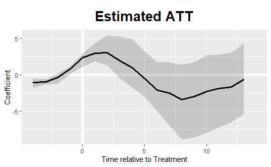

```r
plot(out_n2)#, ylim = c(-5000, 2000))
```

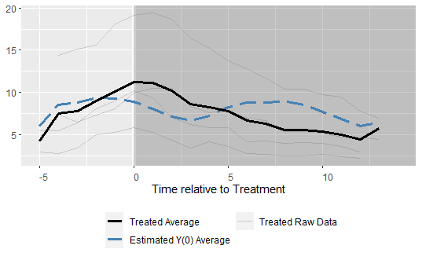

```r
# plot all data:
plot(out_n2, type = "counterfactual",
     raw = "all", main="") # Why the final dip
```

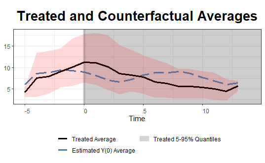

```r
# We can also add two 5 to 95% quantile bands of the treated and control outcomes as references to make sure the estimated counterfactuals are not results of severe extrapolations.

plot(out_n2, type = "counterfactual",
     raw = "band", xlab = "Time",
     # ylim = c(-5,35),
     theme.bw = TRUE)
```

```
DE13 not in the treatment groupDE23 not in the treatment groupDEB3 not in the treatment groupDE50 not in the treatment groupDED5 not in the treatment group
```

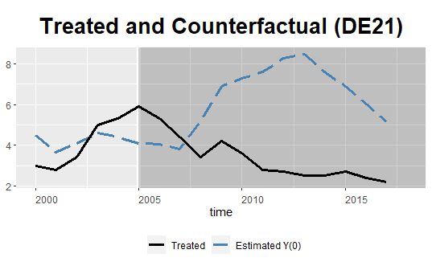

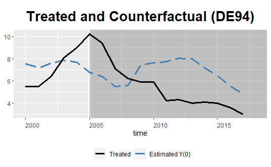

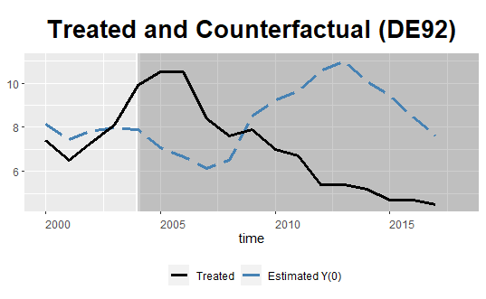

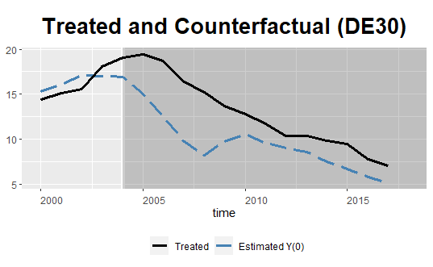

```r
for (i in n2_dta[n2_dta$treated_uz == TRUE, ]$geo %>% unique()){
  plot(out_n2, type = "counterfactual", id = i) # Berlin
}
```

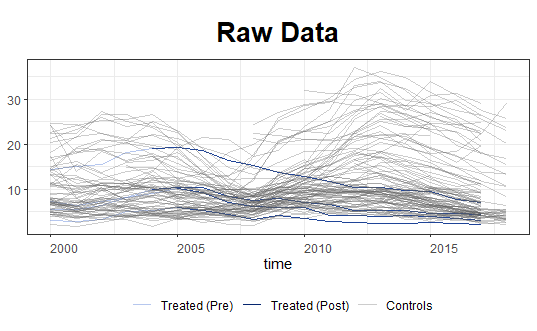

```r
plot(out_n2, type = "raw", theme.bw = TRUE)
```

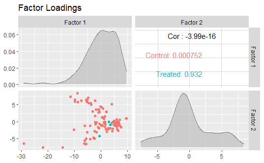

```r
plot(out_n2, type = "loadings")
```

**Conclusions** * BAD parallel trends in average BAD in specific cities * Very strong differences in raw data

### 2. Restr. countries

- Filter countries that have strong shocks of unemployment -> YES https://data.worldbank.org/indicator/SL.UEM.TOTL.NE.ZS?locations=DE-ES-GR-PL-NL-PT-LU-CZ-HU
- Filter regions -> NO
- 60km buffer arround each city center
- FE: TIME + UNITS

```r
n2_dta <- main_dta %>%
  filter(treated_uz | contr_restr_60km) %>%
  filter(!(country %in% c("ES", "EL", "PT", "PL", "TR")))

out_n2 <- gsynth(unempR_T ~ is_announced_2y + wages_per_worker   + gdp_eur_hab + activity_rate,
               data = n2_dta,
               index = c("geo","time"),
               na.rm = TRUE, # remove
               force = "two-way", # unit or time fixed effects or both?
               # CV = TRUE,
               r = c(0, 3), # an integer specifying the number of factors. If CV = TRUE, the cross validation procedure will select the optimal number of factors from r to 5.
               se = TRUE,
               EM = TRUE, # Gobillon and Magnac (takes a lot of time)
               # inference = "parametric",
               # estimator = "mc",
               nboots = 200,  #500
               parallel = TRUE, cores = 5, # if do parallel and how many cores
               min.T0 = 5) # Has to be larger than r.max+1
```

[output not shown]

```r
out_n2 %>% print()
```

```
Call:
gsynth.formula(formula = unempR_T ~ is_announced_2y + wages_per_worker +
    gdp_eur_hab + activity_rate, data = n2_dta, na.rm = TRUE,
    index = c("geo", "time"), force = "two-way",
    r = c(0, 3), EM = TRUE, se = TRUE, nboots = 200, parallel = TRUE,
    cores = 5, min.T0 = 5)

Average Treatment Effect on the Treated:
 ATT.avg  S.E. CI.lower CI.upper p.value
  -1.368 0.891   -3.197   0.4621    0.13

   ~ by Period (including Pre-treatment Periods):
        ATT   S.E. CI.lower CI.upper p.value n.Treated
-4  0.18522 0.1431  -0.2159   0.3604    0.41         0
-3 -0.20343 0.2074  -0.5296   0.2215    0.44         0
-2 -0.04847 0.2498  -0.5712   0.3625    0.87         0
-1 -0.03944 0.2160  -0.3477   0.4733    0.98         0
0   0.12175 0.1499  -0.2577   0.4247    0.37         0
1   0.20837 0.5891  -0.8634   1.3144    0.67         4
2   0.17870 1.0646  -1.8667   1.7979    0.99         4
3  -0.25630 1.1319  -2.5032   1.5181    0.61         4
4   0.07746 1.3737  -2.5469   2.8813    0.89         4
5   0.35385 1.6386  -2.4729   4.0470    0.99         4
6  -0.18069 1.3483  -2.2451   2.4664    0.78         4
7  -0.62631 1.1351  -2.7097   0.9853    0.39         4
8  -1.95652 1.4220  -5.0176   0.4995    0.11         4
9  -2.54094 1.7704  -6.1197   1.1368    0.16         4
10 -3.20429 1.9429  -6.2565   0.8517    0.15         4
11 -3.45805 2.2108  -6.8646   1.2573    0.18         4
12 -3.25305 2.5458  -7.7960   2.3090    0.24         4
13 -4.88420 3.3428 -10.1974   2.4447    0.19         2
14      NaN     NA       NA       NA     NaN         0

Coefficients for the Covariates:
                       beta      S.E.   CI.lower  CI.upper
wages_per_worker -6.503e-05 8.794e-05 -0.0002284 1.507e-04
gdp_eur_hab      -1.049e-04 1.313e-04 -0.0004503 6.507e-05
activity_rate    -6.249e-05 1.563e-03 -0.0030579 3.336e-03
                 p.value
wages_per_worker    0.32
gdp_eur_hab         0.16
activity_rate       0.96
```

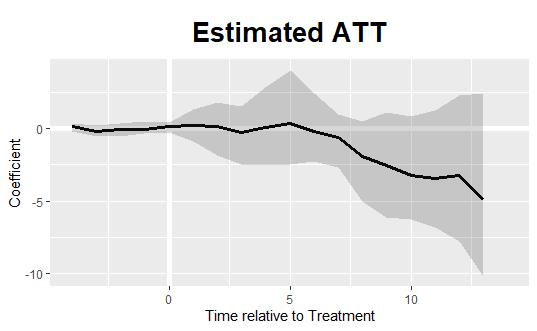

```r
plot(out_n2)#, ylim = c(-5000, 2000))
```

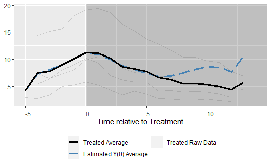

```r
# plot all data:
plot(out_n2, type = "counterfactual",
     raw = "all", main="") # Why the final dip
```

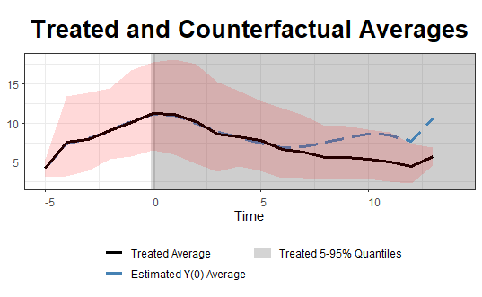

```r
# We can also add two 5 to 95% quantile bands of the treated and control outcomes as references to make sure the estimated counterfactuals are not results of severe extrapolations.

plot(out_n2, type = "counterfactual",
     raw = "band", xlab = "Time",
     # ylim = c(-5,35),
     theme.bw = TRUE)
```

```
DE13 not in the treatment groupDE23 not in the treatment groupDEB3 not in the treatment groupDE50 not in the treatment groupDED5 not in the treatment group
```

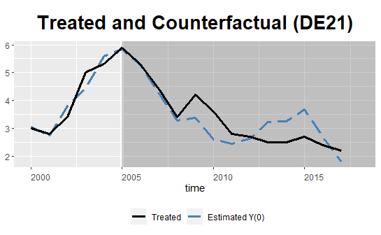

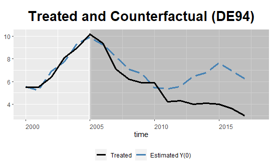

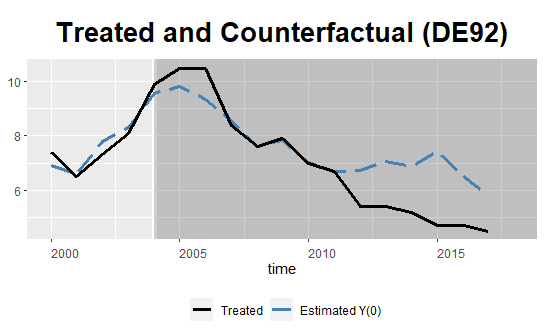

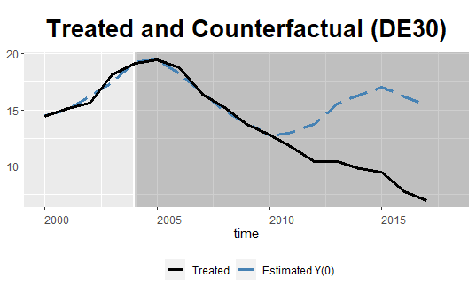

```r
for (i in n2_dta[n2_dta$treated_uz == TRUE, ]$geo %>% unique()){
  plot(out_n2, type = "counterfactual", id = i) # Berlin
}
```

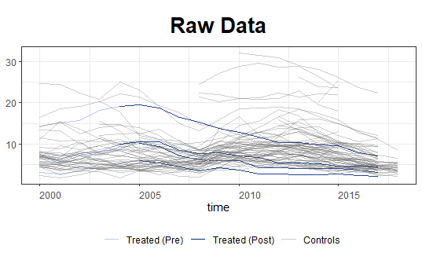

```r
plot(out_n2, type = "raw", theme.bw = TRUE)
```

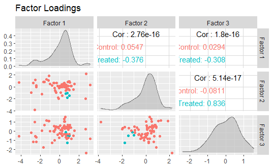

```r
plot(out_n2, type = "loadings")
```

**Conclusions** * GOOD parallel trends in average GOOD in specific cities * LESS strong differences in raw data

### 3. R. Un + co

- Filter countries that have strong shocks of unemployment -> YES https://data.worldbank.org/indicator/SL.UEM.TOTL.NE.ZS?locations=DE-ES-GR-PL-NL-PT-LU-CZ-HU
- Filter regions -> YES
- 60km buffer arround each city center
- Filter regions with high unemployment rates that are not compatiable if I am using fixed effects by region. -> YES

```r
n2_dta <- main_dta %>%
  filter(treated_uz | contr_restr_60km) %>%
  filter(!(country %in% c("ES", "EL", "PT", "PL", "TR"))) %>%
  # filter(!(geo %in% not_optimal_treated)) %>%
  group_by(geo) %>%
  filter(mean(unempR_T, na.rm = TRUE) < 15) %>%
  filter(
    # mean(wages_per_worker, na.rm = TRUE) < ,
    mean(wages_per_worker, na.rm = TRUE) > 10000
  ) %>%
  filter(
    mean(inv_per_worker, na.rm = TRUE) < 25000,
    # mean(inv_per_worker, na.rm = TRUE) > 5000
  ) %>%
  filter(
    # mean(gdp_eur_hab, na.rm = TRUE) < 65000,
    mean(gdp_eur_hab, na.rm = TRUE) > 5000
  ) %>%
  ungroup()

out_n2 <- gsynth(unempR_T ~ is_announced_2y + wages_per_worker   + gdp_eur_hab, # inv_per_worker (only since 2002)
               data = n2_dta,
               index = c("geo","time"),
               na.rm = TRUE, # remove
               force = "two-way", # unit or time fixed effects or both?
               # CV = TRUE,
               r = c(0, 3), # an integer specifying the number of factors. If CV = TRUE, the cross validation procedure will select the optimal number of factors from r to 5.
               se = TRUE,
               EM = TRUE, # Gobillon and Magnac (takes a lot of time)
               inference = "parametric",
               # estimator = "mc",
               nboots = 300,  #500
               parallel = TRUE, cores = 5, # if do parallel and how many cores
               min.T0 = 5) # Has to be larger than r.max+1
```

```
Some treated units has too few pre-treatment periods.
They will be automatically removed.
Parallel computing ...
Cross-validating ...

 r = 0; sigma2 = 3.14715; IC = 1.16566; MSPE = 3.23162
 r = 1; sigma2 = 1.34436; IC = 0.94732; MSPE = 2.92238
 r = 2; sigma2 = 0.91847; IC = 1.17943; MSPE = 0.34718*
 r = 3; sigma2 = 0.58703; IC = 1.32573; MSPE = 0.41512

 r* = 2


Bootstrapping ...

list of removed treated units: DE13 DE50 DED5
```

```r
out_n2 %>% print()
```

```
Call:
gsynth.formula(formula = unempR_T ~ is_announced_2y + wages_per_worker +
    gdp_eur_hab, data = n2_dta, na.rm = TRUE, index = c("geo",
    "time"), force = "two-way", r = c(0, 3), EM = TRUE,
    se = TRUE, nboots = 300, inference = "parametric",
    parallel = TRUE, cores = 5, min.T0 = 5)

Average Treatment Effect on the Treated:
 ATT.avg   S.E. CI.lower CI.upper p.value
  -1.818 0.3634    -2.61   -1.242       0

   ~ by Period (including Pre-treatment Periods):
        ATT   S.E. CI.lower CI.upper p.value n.Treated
-4  0.10979 0.2405  -0.3611   0.5642 0.55333         0
-3 -0.10270 0.2651  -0.6185   0.3598 0.62667         0
-2 -0.03541 0.2763  -0.6021   0.4333 0.78667         0
-1 -0.09267 0.2106  -0.5059   0.3236 0.66000         0
0   0.12583 0.2118  -0.2217   0.6013 0.39333         0
1   0.06521 0.5764  -1.1260   1.0819 0.98000         4
2  -0.01444 0.8952  -1.8301   1.6439 0.76000         4
3  -0.38591 0.9889  -2.2669   1.3076 0.66667         4
4  -0.05405 0.7890  -1.2837   1.4180 0.98667         4
5   0.10529 0.8378  -1.4316   1.9019 0.97333         4
6  -0.55575 0.8654  -2.4387   1.0201 0.30667         4
7  -1.39318 0.7342  -3.0803  -0.2015 0.02667         4
8  -2.97960 0.6447  -4.5414  -1.9529 0.00000         4
9  -3.66354 0.5687  -4.7493  -2.7060 0.00000         4
10 -4.05638 0.4753  -5.0797  -3.1529 0.00000         4
11 -3.76927 0.4617  -4.6332  -2.9259 0.00000         4
12 -3.42642 0.5851  -4.6401  -2.5090 0.00000         4
13 -5.18770 0.8370  -6.8551  -3.4944 0.00000         2
14      NaN     NA       NA       NA     NaN         0

Coefficients for the Covariates:
                       beta      S.E.   CI.lower   CI.upper
wages_per_worker -0.0001224 4.382e-05 -0.0003128 -0.0001458
gdp_eur_hab      -0.0001008 3.296e-05 -0.0001057  0.0000240
                 p.value
wages_per_worker     0.0
gdp_eur_hab          0.2
```

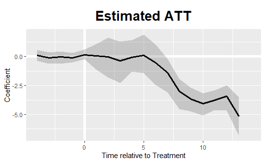

```r
plot(out_n2)#, ylim = c(-5000, 2000))
```

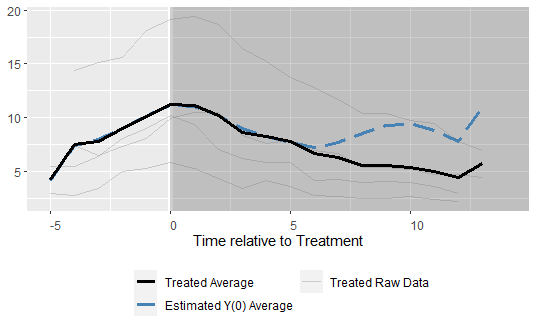

```r
# plot all data:
plot(out_n2, type = "counterfactual",
     raw = "all", main="") # Why the final dip
```

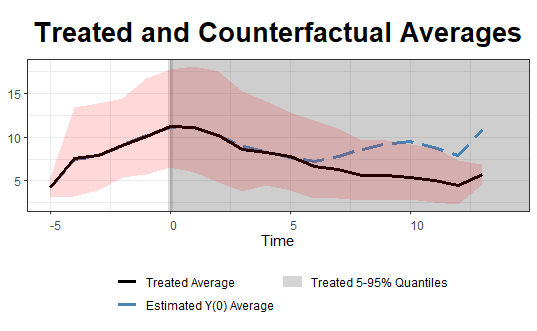

```r
# We can also add two 5 to 95% quantile bands of the treated and control outcomes as references to make sure the estimated counterfactuals are not results of severe extrapolations.

plot(out_n2, type = "counterfactual",
     raw = "band", xlab = "Time",
     # ylim = c(-5,35),
     theme.bw = TRUE)
```

```
DE13 not in the treatment groupDE23 not in the treatment groupDEB3 not in the treatment groupDE50 not in the treatment groupDED5 not in the treatment group
```

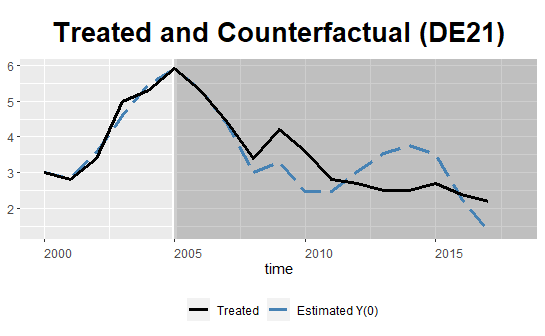

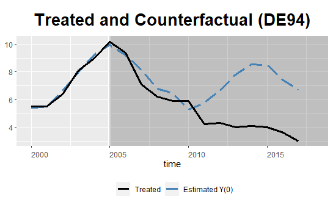

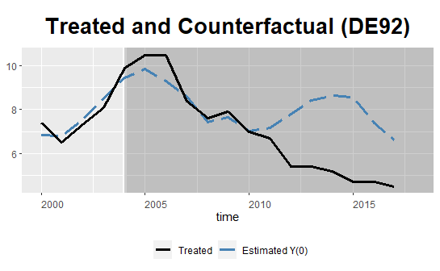

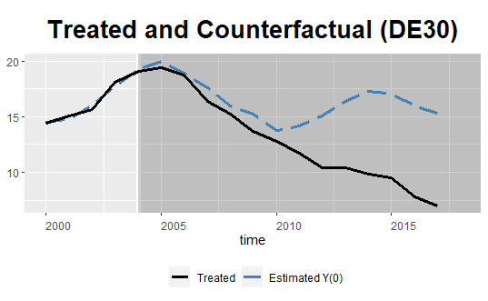

```r
for (i in n2_dta[n2_dta$treated_uz == TRUE, ]$geo %>% unique()){
  plot(out_n2, type = "counterfactual", id = i) # Berlin
}
```

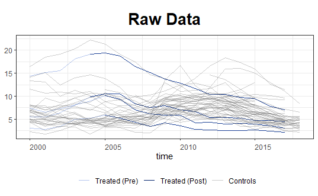

```r
plot(out_n2, type = "raw", theme.bw = TRUE)
```

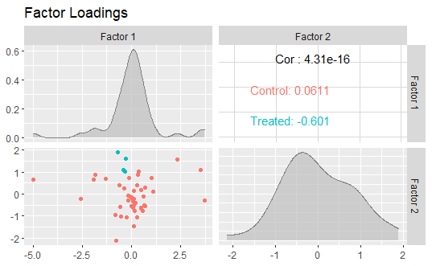

```r
plot(out_n2, type = "loadings")
```

**Conclusions** * GOOD parallel trends in average AND in specific cities * LOW differences in raw data, possibly relevant if I’m going unit FE.